[← Back to All Parables](https://www.kameronyork.com/parables/)

# The Friend at Night

by Kameron York

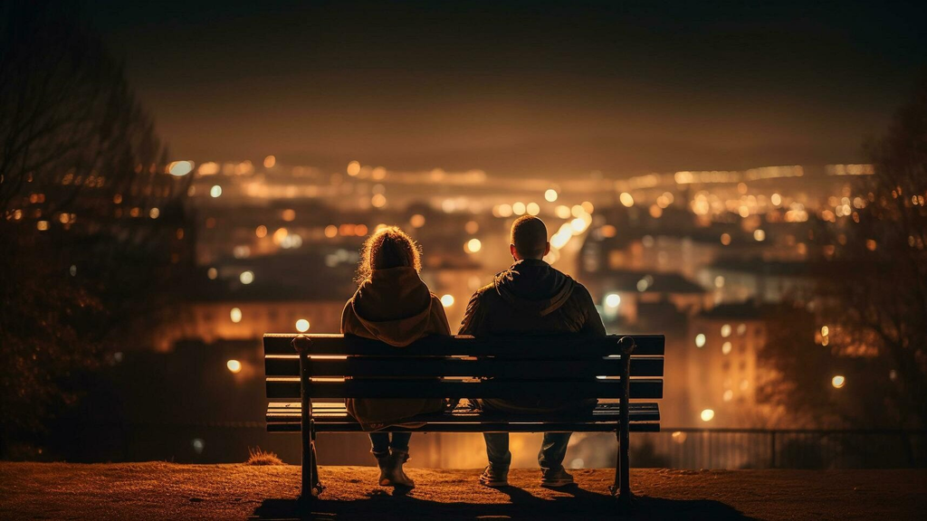

#### Reference:

[Luke 11:5-8](https://www.churchofjesuschrist.org/study/scriptures/nt/luke/11?lang=eng&id=5-8#p5)

#### What is the Parable of the Friend at Night About?

In the parable of the friend at night Jesus highlights the relationship between two friends. In the story one man welcome’s a friend who is, “in his journey”, only to realize he has no food to offer. Seeing this as a lack of hospitality the man heads to a friend’s house to ask for three loaves of bread. There’s only one issue: it’s the middle of the night. When the man arrives at his friend’s house, knocks on the door, and asks for three loaves the friend responds, “Trouble me not, the door is now shut, and my children are with me in bed; I cannot rise and give thee.” This is perfectly a reasonable response! Nobody wants to be woken up in the middle of the night to a friend asking for bread.

But, the story doesn’t end there. According to the parable the man at the door continues to ask and knock. Because of the man’s persistence the friend eventually gets out of bed and gives him the three loaves he’s been seeking. So, what’s the lesson in this parable? That we can get free bread through bothering our friends long enough? Not quite!

#### What is the Meanings of the Parable of the Friend at Night?

In this parable Jesus is teaching an important lesson: God will bless us if we ask. Throughout scriptures there is an important emphasis on **asking** for blessings. Jesus teaches that parents wouldn’t give a stone to a hungry child and says, “how much more shall your Father which is in heaven give good things to them that ask him?” (Note that Jesus says we need to ask of God). Think of James 1:5, “…let him ask of God, that giveth to all men liberally, and upbraideth not; and it shall be given him.” Clearly God wants to bless us, but there is a power to asking for blessings from God!

But, what about the prayers that aren’t answered? Every day people pray for important things and never receive them. Do these people just need to pray harder or more often to make God give them their metaphorical loaves of bread? Isn’t the meaning of Jesus’ parable that God will give us what we want if we ask enough times? No, unfortunately that’s not the meaning. One of the most important qualities of our God is His ability to say no to our prayers. Because He is an omnipotent God He knows the best outcome for us and has the ability to take our lives in a direction we can’t forsee.

So, how does this concept fit into the parable of the friend at night? Imagine the parable like this: The man reaches his friend’s house asking for three loaves of white bread. After some convincing the friend gets out of bed, opens the door, and hands the man three loaves of wheat bread. The man thinks, “This isn’t what I asked for! I asked for white bread. Clearly my request wasn’t answered.” Imaging it this way: The man asks for three loaves of white bread, and his friend opens the door to give him only one loaf of white bread. In this instance he received the right bread but the wrong amount, was his request answered? God doesn’t need to answer our prayers in the way we think best, but He will answer our prayers. Sometimes we pray for a loved one to be healed and they aren’t. Sometimes we pray for a promotion and get passed up. Sometimes we pray for guidance and feel nothing. I hope, in those instances, that we are looking for how God HAS answered our prayers and not focusing on the incorrect type of bread or missing loaves.

God will answer our prayers in His time and in His way, but the parable of the friend at night teaches us that God will answer the prayers of those who ask.